# Comparing films

That’s my mini-research project based on ratings of films. I am trying to compare films The Hobbit, Bohemian Rhapsody and Hachi and define some hypotheses to prove them or deny. After that I will decide which movie I will watch right after passing course “Probability and statistics” (better known as “Probability” or “Probabilka” among my groupmates). Firstly, I took information about ratings of these films from IMDb.com and create histograms of their ratings.  
Let’s look at the rating of **The Hobbit**

```r
freq <- c(17075, 2985, 4817, 8817, 21308, 55475, 130798, 202330, 136160, 139720)
values <- c(1, 2, 3, 4, 5, 6, 7, 8, 9, 10)
df <- data.frame(values,freq)
vec <- rep(df$value, df$freq)
library(ggplot2)
ggplot(df, aes(x = values, y = freq)) +
       geom_bar(stat="identity", fill="#8BC837")
```

[output not shown]

And that’s the rating of **Bohemian Rhapsody**

```r
freq_2 <- c(1162, 317, 548, 1065, 2721, 7524, 19944, 39728, 46733, 55121)
values_2 <- c(1, 2, 3, 4, 5, 6, 7, 8, 9, 10)
df_2 <- data.frame(values_2,freq_2)
vec_2 <- rep(df_2$value, df_2$freq)

library(ggplot2)
ggplot(df_2, aes(x = values_2, y = freq_2)) +
       geom_bar(stat="identity", fill="#8E2CAB")
```

[output not shown]

And the last but not least, **Hachi**

```r
freq_3 <- c(1853, 822, 1134, 1862, 4714, 12141, 32883, 57383, 42295, 58050)
values_3 <- c(1, 2, 3, 4, 5, 6, 7, 8, 9, 10)
df_3 <- data.frame(values_3,freq_3)
vec_3 <- rep(df_3$value, df_3$freq)
library(ggplot2)
ggplot(df_3, aes(x = values_3, y = freq_3)) +
       geom_bar(stat="identity", fill="#EDA30F")
```

[output not shown]

Now I will examine each rating distribution to understand more about the central trend of votes.

**Ratings of The Hobbit**

```r
print(paste0("median - ", median(vec)))
```

```
[1] "median - 8"
```

```r
print(paste0("mean - ", mean(vec)))
```

```
[1] "mean - 7.87927475902904"
```

```r
print(paste0("standard deviation - ", sd(vec)))
```

```
[1] "standard deviation - 1.83953568024086"
```

**Ratings of Bohemian Rhapsody**

```r
print(paste0("median - ", median(vec_2)))
```

```
[1] "median - 9"
```

```r
print(paste0("mean - ", mean(vec_2)))
```

```
[1] "mean - 8.55348472804424"
```

```r
print(paste0("standard deviation - ", sd(vec_2)))
```

```
[1] "standard deviation - 1.48818808950242"
```

**Ratings of Hachi**

```r
print(paste0("median - ", median(vec_3)))
```

```
[1] "median - 8"
```

```r
print(paste0("mean - ", mean(vec_3)))
```

```
[1] "mean - 8.26305615636891"
```

```r
print(paste0("standard deviation - ", sd(vec_3)))
```

```
[1] "standard deviation - 1.62404399890248"
```

Wow! Honestly, I didn’t expect such from Bohemian Rhapsody! Is it that good? I didn’t watch it! Well, it has good chances to win! Okay, let’s run some statistical tests to compare these distributions and define a winner!

Here I will use Q-Q Plots and quantilies and compare ratings distribution with normal one.

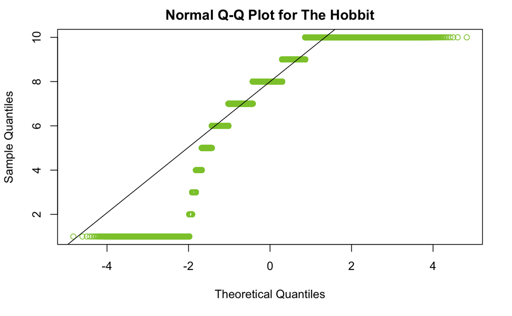

```r
qqnorm(vec, col="#8BC837", main = "Normal Q-Q Plot for The Hobbit")
qqline(vec)
```

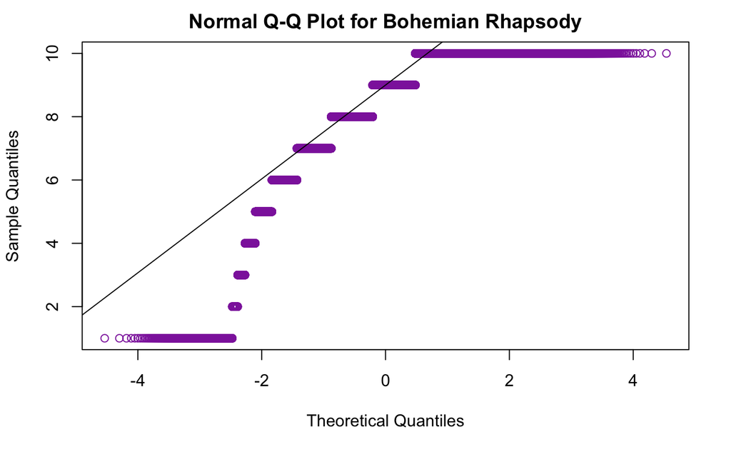

```r
qqnorm(vec_2, col="#8E2CAB", main = "Normal Q-Q Plot for Bohemian Rhapsody")
qqline(vec_2)
```

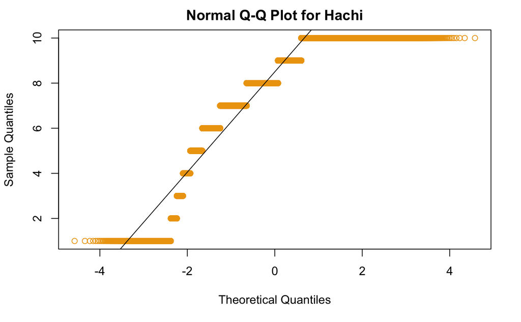

```r
qqnorm(vec_3, col="#EDA30F", main = "Normal Q-Q Plot for Hachi")
qqline(vec_3)
```

Now I have to define hypotheses and set the significance level of the test. For my case I will estimate: is one movie much better than another? Hypothesis will be built on the difference between the average ratings of films on IMDb.

Let’s denote our Hypotheses:

H0: µ1 = µ2

H1: µ1 ≠ µ2

That means: The mean of the first film is equal to the mean of the second movie (H_0). And the mean of the first film is not equal to the mean of the second movie (H_1). Now we will try to reject H_0 by statistical test which states that there is no observable changes.

Let’s define our significanse level as a = 0.05. That’s the probability the H_0 will be rejected when it was true.

### The Hobbit vs Bohemian Rhapsody

```r
ttest <- t.test(vec, vec_2)
print(paste0("test-statistic - ", ttest$statistic))
```

```
[1] "test-statistic - -161.775603154432"
```

```r
print(paste0("p-value - ", ttest$p.value))
```

```
[1] "p-value - 0"
```

### The Hobbit vs Hachi

```r
ttest_2 <- t.test(vec, vec_3)
print(paste0("test-statistic - ", ttest_2$statistic))
```

```
[1] "test-statistic - -92.867931320644"
```

```r
print(paste0("p-value - ", ttest_2$p.value))
```

```
[1] "p-value - 0"
```

### Bohemian Rhapsody vs Hachi

```r
ttest_3 <- t.test(vec_2, vec_3)
print(paste0("test-statistic - ", ttest_3$statistic))
```

```
[1] "test-statistic - 58.0391578186132"
```

```r
print(paste0("p-value - ", ttest_3$p.value))
```

```
[1] "p-value - 0"
```

As you can see test-statistic is very large so there is significant difference between the two pairs movie. In addition, our p-value is so tiny that R even can’t show it to us. That means that we can reject H_0 which states that there is no big difference between the two pairs movie as p-value is much smaller than the significance level of 0.05.

Now after showing that there is the difference in movies and ratings means, I will choose a movie to watch according to means. Let’s remember that

```r
mean(vec)
mean(vec_2)
mean(vec_3)
```

**The Hobbit**

mean - 7.879275

**Bohemian Rhapsody**

mean - 8.553485

**Hachi**

mean - 8.263056

So it seems that after passing course “Probability and Statistics” I will watch Bohemian Rhapsody! I have not watched it yet but I have proofs that it is the best option! And there is a question for you: What is the probability that all our groups and Mr.Rostyslav Hryniv will watch this film to have a good end of this course together? :)